# mtcars

```r
library(tidyverse)
library(psych)
library(lm.beta)
library(car)
```

Let’s load in the data for this exploratory data analysis. This is one of the datasets that is included in R called The Motor Trend Car Road Tests (mtcars). To get a deeper look at the dataset, the command ‘?mtcars’ can be used. The dataset includes extracted information from the 1974 Motor Trend magazine. It includes 10 aspects of automobile design and performance for 32 cars (1973-1974 models only).

```r
data(mtcars)
```

Another way to learn more about the dataset is to use the ‘names()’ command. This command will give you all of the variable names in the dataset. The next step would be looking at what types of variables each one is which is accomplished by using the ‘str()’ command.

```r
names(mtcars)
```

```
##  [1] "mpg"  "cyl"  "disp" "hp"   "drat" "wt"   "qsec" "vs"   "am"   "gear"
## [11] "carb"
```

```r
str(mtcars)
```

```
## 'data.frame':    32 obs. of  11 variables:
##  $ mpg : num  21 21 22.8 21.4 18.7 18.1 14.3 24.4 22.8 19.2 ...
##  $ cyl : num  6 6 4 6 8 6 8 4 4 6 ...
##  $ disp: num  160 160 108 258 360 ...
##  $ hp  : num  110 110 93 110 175 105 245 62 95 123 ...
##  $ drat: num  3.9 3.9 3.85 3.08 3.15 2.76 3.21 3.69 3.92 3.92 ...
##  $ wt  : num  2.62 2.88 2.32 3.21 3.44 ...
##  $ qsec: num  16.5 17 18.6 19.4 17 ...
##  $ vs  : num  0 0 1 1 0 1 0 1 1 1 ...
##  $ am  : num  1 1 1 0 0 0 0 0 0 0 ...
##  $ gear: num  4 4 4 3 3 3 3 4 4 4 ...
##  $ carb: num  4 4 1 1 2 1 4 2 2 4 ...
```

All of the variables are numerical and there don’t look to be any missing values. Just to start out, lets look at the relation between miles per gallon and horsepower. One would expect that as horsepower increases, the car would use more gas and thus not be as efficient. We can look at this both visually using a graph and look at the relation statistically using a correlation test.

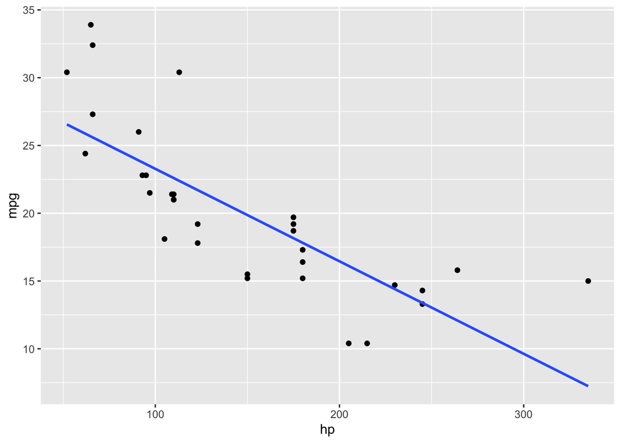

```r
ggplot(data = mtcars, aes(x = hp, y = mpg)) + geom_point() + geom_smooth(method = "lm", se = FALSE)
```

```r
cor.test(mtcars$mpg, mtcars$hp)
```

```
##
##  Pearson's product-moment correlation
##
## data:  mtcars$mpg and mtcars$hp
## t = -6.7424, df = 30, p-value = 1.788e-07
## alternative hypothesis: true correlation is not equal to 0
## 95 percent confidence interval:
##  -0.8852686 -0.5860994
## sample estimates:
##        cor
## -0.7761684
```

As expected, there is a negative relation between the two variables in that as horsepower increases, miles per gallon decrease. This relation is statistically significant and thus can be generalized to other similar cars not included in the dataset (r = -0.78, p < .001). Although there was no random sampling involved in this data, these findings likely would be able to generalize to other older cars. These findings may not be generalizable to newer cars. Because the p value is so low, there is an extremely low chance of obtaining this difference by chance alone. Additionally, the magnitude of the relation is extremely strong.

Let’s calculate a quick predictive model to represent how much we can expect mpg to change in response to modifying the horsepower.

```r
lm.shape <- lm(mpg ~ hp, data = mtcars)
lm.shape.beta <- lm.beta(lm.shape)
summary(lm.shape.beta)
```

```
##
## Call:
## lm(formula = mpg ~ hp, data = mtcars)
##
## Residuals:
##     Min      1Q  Median      3Q     Max
## -5.7121 -2.1122 -0.8854  1.5819  8.2360
##
## Coefficients:
##             Estimate Standardized Std. Error t value Pr(>|t|)
## (Intercept) 30.09886      0.00000    1.63392  18.421  < 2e-16 ***
## hp          -0.06823     -0.77617    0.01012  -6.742 1.79e-07 ***
## ---
## Signif. codes:  0 '***' 0.001 '**' 0.01 '*' 0.05 '.' 0.1 ' ' 1
##
## Residual standard error: 3.863 on 30 degrees of freedom
## Multiple R-squared:  0.6024, Adjusted R-squared:  0.5892
## F-statistic: 45.46 on 1 and 30 DF,  p-value: 1.788e-07
```

This regression model indicates that for every increase of 1 HP, we can expect a decrease in MPG by -0.07. The standardized coeffiecient was included to emphasize that a beta weight is equivalent to a correlation coefficient if there is nothing being controlled for. Lets take this model and see what it would predict the MPG would be for a car with 300 HP like the Genesis Coupe. To do this, we will first need to create a new data frame for the Genesis Coupe and input the HP. Then we will be able to use the model specified above to predict how many MPGs the Genesis Coupe would get.

```r
gencoupe <- data.frame(hp = 300)
predict(lm.shape, gencoupe)
```

```
##        1
## 9.630377
```

This model would predict that the 2017 Genesis Coupe with 300 HP would get about 9.63 MPG. That is much lower than the true MPG of the Genesis Coupe which is about 30. Remember that the model only included cars built in 1973 and 1974 so generalizing too far outside that time range is not appropriate. In order to properly generalize to a newer car like the Genesis Coupe, we would need to include newer cars in the dataset and optimally would use the year the car was made as a predictor rather than just HP alone.

Having said all that, let’s take a little deeper look to see if there even were cars with 300 HP included in the dataset. If there weren’t, we should be even more hesitant to believe this prediction as the model may not have had any cars that powerful included. We must be careful not to generalize our regression too far outside the bounds of the dataset. We will do this in two ways. The first way will return the range of HP included in the dataset and the second way will sort our dataset by HP in descending order and will return the first several values.

```r
mtcars %>% select(hp) %>% range()
```

```
## [1]  52 335
```

```r
sort(mtcars$hp, decreasing = TRUE) %>% head()
```

```
## [1] 335 264 245 245 230 215
```

Sure enough, there was one car that had 335 HP included in the dataset. However, that was the only car that was over 300 HP. Cars in those days were nowhere near as powerful as they are now. Clearly the technology has changed from 1974 and this regression model does not account for that. My point here is: be careful what you generalize to. There is no statistical analysis that can allow you to infer causality or generalizability; that has to do with the methodology (e.g. sampling type and assignment strategy).

Let’s now take a look at some other variables and relations that may not be as obvious. First, let’s transform the numerical ‘vs’ variable to a factor with two levels. This variable represents the shape of the engine which is either V-shaped or straight. We will save this factor as a new variable so that we can still use the numeric version when needed. Making the variable a factor just makes it a little easier to read in some situations like graphs and descriptive statistics.

After that, we will create a graph of the avg MPG for each type of engine shape (v-shaped and straight) to see if one engine shape is more efficient than the other. We want a bar graph because one of our variables is binary and the other is quantitative. Inside of the bar plot, using the commands ‘stat = “summary”, fun.y = “mean”’ allows us to plot the group means rather than some other summary like the ‘stat = “identity”’ command. Additionally, the ‘xlab()’ and ‘ylab()’ commands allow us to add on layers that represent what we want our axis labels to be. Xlab represents the X axis label and similarly ylab represents the Y axis label. Because we already converted the ‘vs’ variable to a factor with the correct labels, those labels will automatically show up on the graph as long as we use the factor we created in the first line of code and not the numerical version.

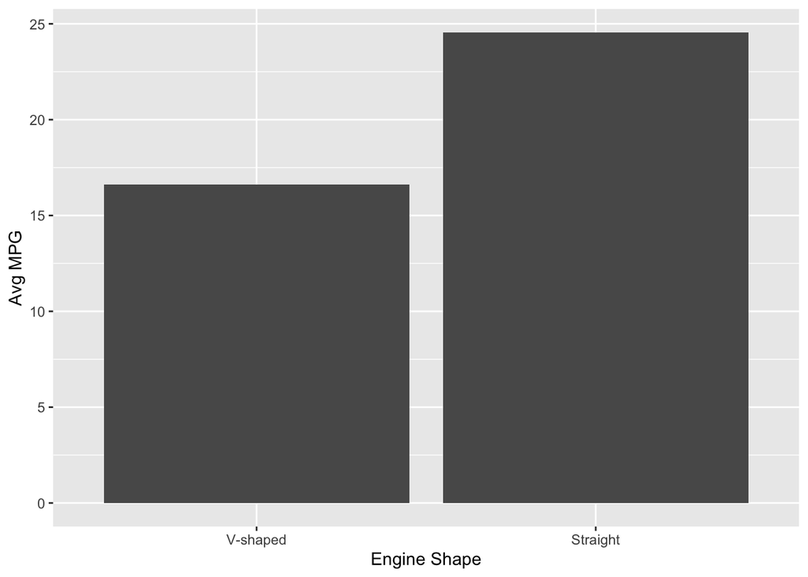

```r
mtcars <- mtcars %>% mutate(vs2 = factor(vs, levels = c(0, 1), labels = c("V-shaped", "Straight")))
ggplot(data = mtcars, aes(x = vs2, y = mpg)) + geom_bar(stat = "summary", fun.y = "mean") + xlab("Engine Shape") + ylab("Avg MPG")
```

As you can see, v shaped engines actually get lower MPG when compared to straight shapes. Let’s look in to this a little deeper..

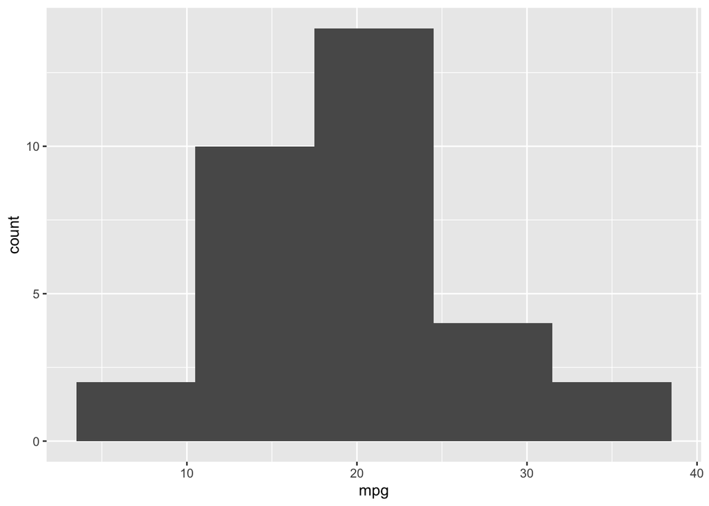

```r
ggplot(data = mtcars, aes(x = mpg)) + geom_histogram(binwidth = 7)
```

```r
describe(mtcars$mpg)
```

```
##    vars  n  mean   sd median trimmed  mad  min  max range skew kurtosis
## X1    1 32 20.09 6.03   19.2    19.7 5.41 10.4 33.9  23.5 0.61    -0.37
##      se
## X1 1.07
```

It appears that MPG is approximately normally distributed with a skewness value of 0.61 and a kurtosis value of -0.37. Both of these values are well within the bounds of normality. Additionally, the histogram appears to be approximately normally distrbuted. One of the assumptions of many statistical methods such as the ones used here require that variables are approximately normally distributed. Now that we know that our main variable is, we can move forward with out analyses. Let’s check out the exact values of the avg MPG per group.

```r
mtcars %>% group_by(vs2) %>% summarise(mean.mpg = mean(mpg))
```

```
## # A tibble: 2 x 2
##   vs2      mean.mpg
##   <fct>       <dbl>
## 1 V-shaped     16.6
## 2 Straight     24.6
```

This echos what the graph told us; that straight engines tend to be more fuel efficient than v-shaped engines. Now let’s see if this difference is statistically significant or if it is likely due to chance.

```r
t.test1 <- t.test(mpg ~ vs, data = mtcars)
t.test1
```

```
##
##  Welch Two Sample t-test
##
## data:  mpg by vs
## t = -4.6671, df = 22.716, p-value = 0.0001098
## alternative hypothesis: true difference in means is not equal to 0
## 95 percent confidence interval:
##  -11.462508  -4.418445
## sample estimates:
## mean in group 0 mean in group 1
##        16.61667        24.55714
```

It appears that straight engines (m = 24.56) are significant more fuel efficient than v-shaped engines (m = 16.62), t(22.72) = -4.67, p < .001. We are now able to say that this difference is extremely unlikely to occur by chance.

This finding is strange though.. If you are familiar with cars and engine shapes, you probably know that v shaped engines tend to be used with engines that have more than 4 cylinders whereas straight engine shapes tend to be used with engines that have 4 cylinders. Also, you may be aware that as an engine has more cylinders, it uses more gas and therefore is likely to become less fuel efficient. Perhaps the difference in fuel efficiency between v-shaped engines and straight shaped engines is actually due to the number of cylinders it has and not the shape of the engine itself. To do this, we will create a new regression model that controls for the number of cylinders.

Let’s go over what setting up a regression is like briefly. First you must create an object in the r enviornment that represents your regression. This is done in the first line of the code which specifies the name of the object that represents the regression model, and also specifies the equation of the model, the dataset, and the the type of model it is (in this case a linear regression model). The second line of code adds standardized regression weights to the model. The third line of code gives a summary of the model created in the previous two lines of code and the final line of code returns the VIF values of the model used to diagnose the model.

```r
lm.shape.cyl <- lm(mpg ~ vs + cyl, data = mtcars)
lm.shape.cyl.beta <- lm.beta(lm.shape.cyl)
summary(lm.shape.cyl.beta)
```

```
##
## Call:
## lm(formula = mpg ~ vs + cyl, data = mtcars)
##
## Residuals:
##    Min     1Q Median     3Q    Max
## -4.923 -1.953 -0.081  1.319  7.577
##
## Coefficients:
##             Estimate Standardized Std. Error t value Pr(>|t|)
## (Intercept) 39.62502      0.00000    4.22461   9.380 2.77e-10 ***
## vs          -0.93908     -0.07853    1.97752  -0.475    0.638
## cyl         -3.09067     -0.91584    0.55809  -5.538 5.70e-06 ***
## ---
## Signif. codes:  0 '***' 0.001 '**' 0.01 '*' 0.05 '.' 0.1 ' ' 1
##
## Residual standard error: 3.248 on 29 degrees of freedom
## Multiple R-squared:  0.7283, Adjusted R-squared:  0.7096
## F-statistic: 38.87 on 2 and 29 DF,  p-value: 6.23e-09
```

```r
vif(lm.shape.cyl.beta)
```

```
##      vs     cyl
## 2.91899 2.91899
```

However, because the p value for the engine shape predictor was so high, we can say that it is not significantly different from no relationship. The effect size of -0.08 was very small as well which indicates that not only was the effect non-significant, but it was also very small in size. This regression model confirms our hypothesis; when the number of cylinders was included in the model, the engine shape no longer was a significant predictor of MPG. In other words, this regression model indicates that when number of cylinders is included in a regression model where engine shape is set to predict MPG, the engine shape does not significantly predict MPG even though engine shape would significantly predict MPG if number of cylinders was not controlled for.

To get at this from another angle, let’s calcualte a correlation between number of cylinders and shape of engine. This correlation between a binary variable and a continuous variable is called a Point By Serial Correlation.

```r
cor.test(mtcars$cyl, mtcars$vs)
```

```
##
##  Pearson's product-moment correlation
##
## data:  mtcars$cyl and mtcars$vs
## t = -7.5875, df = 30, p-value = 1.843e-08
## alternative hypothesis: true correlation is not equal to 0
## 95 percent confidence interval:
##  -0.9039393 -0.6442689
## sample estimates:
##        cor
## -0.8108118
```

Sure enough, the correlation is significant and strong. Now that we know that these two variables are highly related, let’s only use one for future models. Let’s continue to use number of cylinders and not include shape of the engine.

Let’s hold off on that for now and switch to investigating some of the other relations in the dataset. Let’s check out the relation between type of transmission (Manual or Automatic) and MPG. We will go through many of the same steps that we wen’t through in the previous analyses.

```r
mtcars <- mtcars %>% mutate(am2 = factor(am, levels = c(0, 1), labels = c("Automatic Trans", "Manual Trans")))
mtcars %>% group_by(am2) %>% summarise(mean.mpg = mean(mpg))
```

```
## # A tibble: 2 x 2
##   am2             mean.mpg
##   <fct>              <dbl>
## 1 Automatic Trans     17.1
## 2 Manual Trans        24.4
```

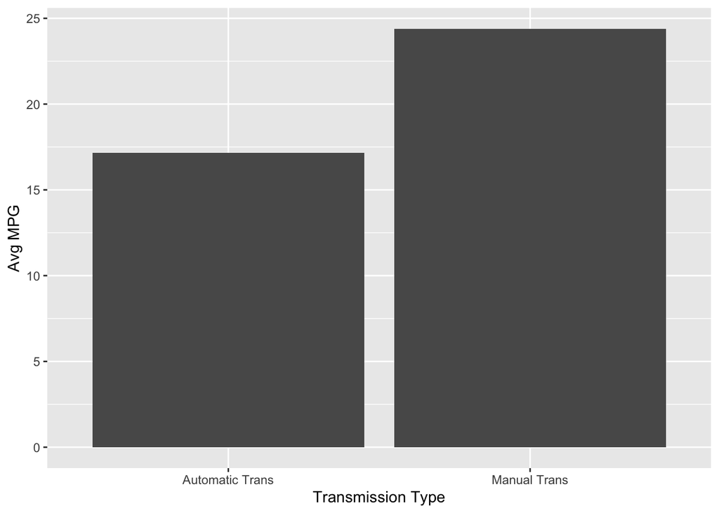

```r
ggplot(data = mtcars, aes(x = am2, y = mpg)) + geom_bar(stat = "summary", fun.y = "mean") + xlab("Transmission Type") + ylab("Avg MPG")
```

```r
t.test2 <- t.test(mpg ~ am, data = mtcars)
t.test2
```

```
##
##  Welch Two Sample t-test
##
## data:  mpg by am
## t = -3.7671, df = 18.332, p-value = 0.001374
## alternative hypothesis: true difference in means is not equal to 0
## 95 percent confidence interval:
##  -11.280194  -3.209684
## sample estimates:
## mean in group 0 mean in group 1
##        17.14737        24.39231
```

Manual transmissions (m = 24.39) get significantly better gas milage than automatic transmissions (m = 17.15), t(18.33) = -3.77, p < .01. Now let’s check out some graphs of the relations between MPG and some other variables in the dataset. If there are a couple that are clearly related with MPG, we can include them all in a final regression model. If all of them are related with MPG, we may have to pick and choose.

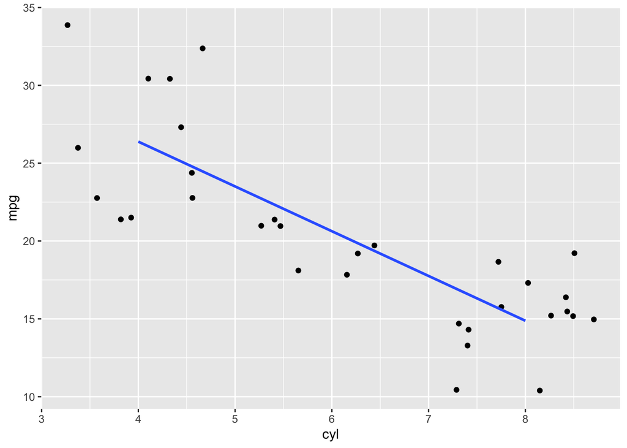

```r
ggplot(data = mtcars, aes(x = cyl, y = mpg)) + geom_jitter() + geom_smooth(method = 'lm', se = FALSE)
```

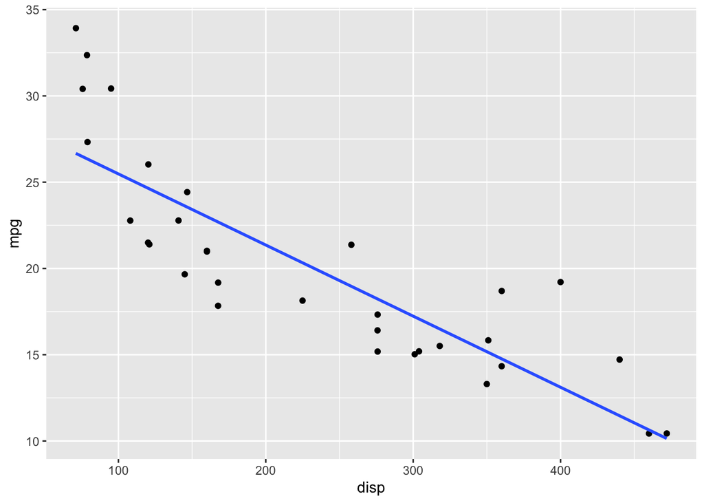

```r
ggplot(data = mtcars, aes(x = disp, y = mpg)) + geom_jitter() + geom_smooth(method = 'lm', se = FALSE)
```

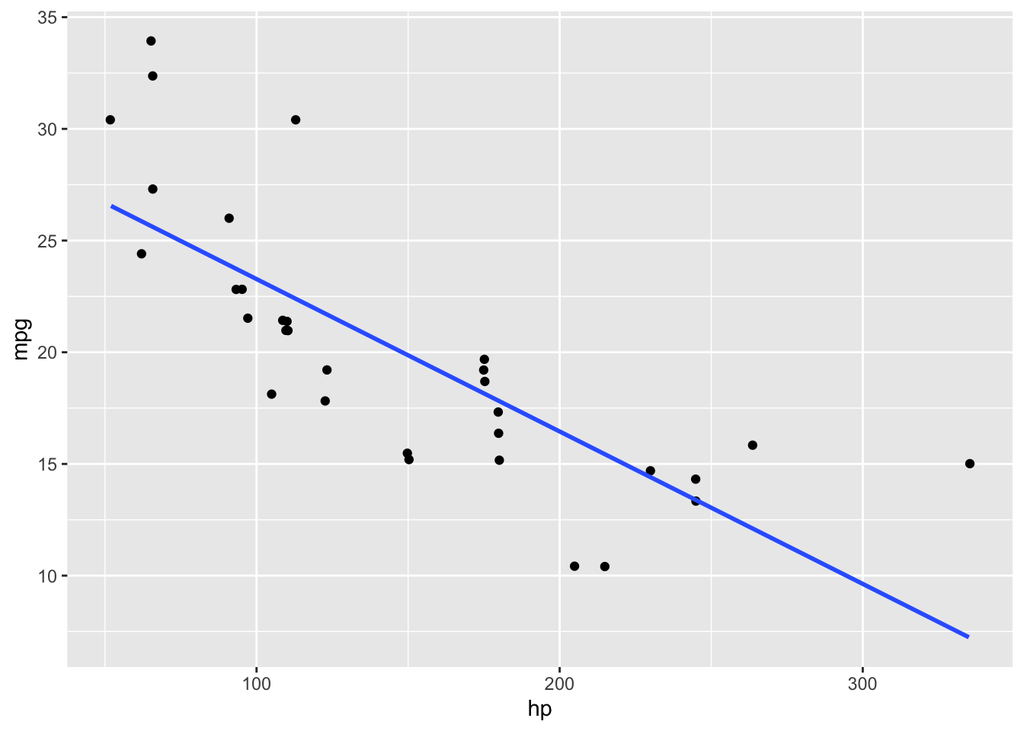

```r
ggplot(data = mtcars, aes(x = hp, y = mpg)) + geom_jitter() + geom_smooth(method = 'lm', se = FALSE)
```

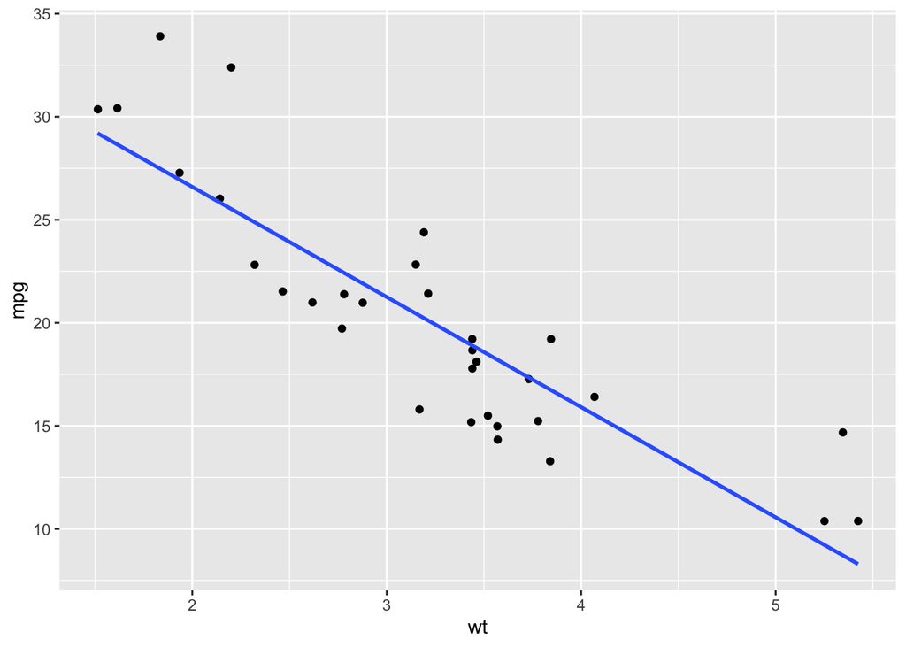

```r
ggplot(data = mtcars, aes(x = wt, y = mpg)) + geom_jitter() + geom_smooth(method = 'lm', se = FALSE)
```

All of them appear to be highly related to MPG so let’s just choose weight and include it. Although we can see that there is a strong relation between MPG and weight of a car, let’s quantify that relation using a correlation.

```r
cor.test(mtcars$wt, mtcars$mpg)
```

```
##
##  Pearson's product-moment correlation
##
## data:  mtcars$wt and mtcars$mpg
## t = -9.559, df = 30, p-value = 1.294e-10
## alternative hypothesis: true correlation is not equal to 0
## 95 percent confidence interval:
##  -0.9338264 -0.7440872
## sample estimates:
##        cor
## -0.8676594
```

This echos what the graph told us. There is a strong significant negative relation between MPG and weight of a car (r = -0.87, p < .001).

Now let’s put all these pieces together and see what kind of model we can come up with. We are going to set weight of the car, horsepower, number of cylinders, and transmission type to predict MPG.

```r
lm1 <- lm(mpg ~ am + cyl + hp + wt, data = mtcars)
lm1.beta <- lm.beta(lm1)
summary(lm1.beta)
```

```
##
## Call:
## lm(formula = mpg ~ am + cyl + hp + wt, data = mtcars)
##
## Residuals:
##     Min      1Q  Median      3Q     Max
## -3.4765 -1.8471 -0.5544  1.2758  5.6608
##
## Coefficients:
##             Estimate Standardized Std. Error t value Pr(>|t|)
## (Intercept) 36.14654      0.00000    3.10478  11.642 4.94e-12 ***
## am           1.47805      0.12237    1.44115   1.026   0.3142
## cyl         -0.74516     -0.22081    0.58279  -1.279   0.2119
## hp          -0.02495     -0.28384    0.01365  -1.828   0.0786 .
## wt          -2.60648     -0.42315    0.91984  -2.834   0.0086 **
## ---
## Signif. codes:  0 '***' 0.001 '**' 0.01 '*' 0.05 '.' 0.1 ' ' 1
##
## Residual standard error: 2.509 on 27 degrees of freedom
## Multiple R-squared:  0.849,  Adjusted R-squared:  0.8267
## F-statistic: 37.96 on 4 and 27 DF,  p-value: 1.025e-10
```

```r
vif(lm1.beta)
```

```
##       am      cyl       hp       wt
## 2.546159 5.333685 4.310029 3.988305
```

So it looks like the regression model is significant, f(4,27) = 37.96, p < .001. However, after controlling for all other variables in the model, weight of the car is the only significant predictor. Horsepower is the next most important predictor in the model, but it is non-significant. Transmission type and number of cylinders are no longer significantly related to MPG after controlling for the other variables.

After looking at the VIF values, it looks like we have some multicollinearity issues here. Let’s think about which variable to delete out of the model to correct this issue. The two variables with the highest VIF values are HP and CYL. This makese sense because as an engine has more cylinders, it is usually able to produce more power. Let’s double check this with a graph and a correlation.

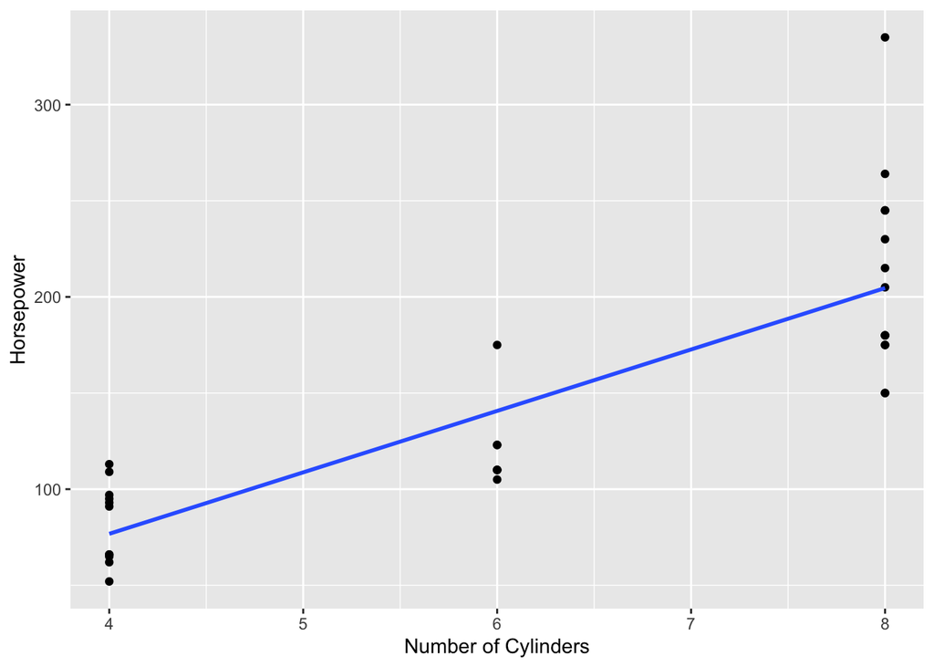

```r
ggplot(mtcars, aes(cyl, hp)) + geom_point() + geom_smooth(method = 'lm', se = FALSE) + xlab("Number of Cylinders") + ylab("Horsepower")
```

```r
cor.test(mtcars$hp, mtcars$cyl)
```

```
##
##  Pearson's product-moment correlation
##
## data:  mtcars$hp and mtcars$cyl
## t = 8.2286, df = 30, p-value = 3.478e-09
## alternative hypothesis: true correlation is not equal to 0
## 95 percent confidence interval:
##  0.6816016 0.9154223
## sample estimates:
##       cor
## 0.8324475
```

This confirms what I stated above. Number of cylinders is highly related to horsepower. Let’s only include horsepower in the next model as it was a stronger predictor.

```r
lm2 <- lm(mpg ~ hp + wt + am, data = mtcars)
lm2.beta <- lm.beta(lm2)
summary(lm2.beta)
```

```
##
## Call:
## lm(formula = mpg ~ hp + wt + am, data = mtcars)
##
## Residuals:
##     Min      1Q  Median      3Q     Max
## -3.4221 -1.7924 -0.3788  1.2249  5.5317
##
## Coefficients:
##              Estimate Standardized Std. Error t value Pr(>|t|)
## (Intercept) 34.002875     0.000000   2.642659  12.867 2.82e-13 ***
## hp          -0.037479    -0.426360   0.009605  -3.902 0.000546 ***
## wt          -2.878575    -0.467328   0.904971  -3.181 0.003574 **
## am           2.083710     0.172517   1.376420   1.514 0.141268
## ---
## Signif. codes:  0 '***' 0.001 '**' 0.01 '*' 0.05 '.' 0.1 ' ' 1
##
## Residual standard error: 2.538 on 28 degrees of freedom
## Multiple R-squared:  0.8399, Adjusted R-squared:  0.8227
## F-statistic: 48.96 on 3 and 28 DF,  p-value: 2.908e-11
```

```r
vif(lm2.beta)
```

```
##       hp       wt       am
## 2.088124 3.774838 2.271082
```

After deleting the number of cylinders as a predictor in the model, the VIF values have gone down indiciating that multicollinearity issues have been reduced. However, transmission type is still not a significant predictor after controlling for weight and horsepower. Let’s take that variable out of the model and see what happens.

```r
lm3 <- lm(mpg ~ hp + wt, mtcars)
lm3.beta <- lm.beta(lm3)
summary(lm3.beta)
```

```
##
## Call:
## lm(formula = mpg ~ hp + wt, data = mtcars)
##
## Residuals:
##    Min     1Q Median     3Q    Max
## -3.941 -1.600 -0.182  1.050  5.854
##
## Coefficients:
##             Estimate Standardized Std. Error t value Pr(>|t|)
## (Intercept) 37.22727      0.00000    1.59879  23.285  < 2e-16 ***
## hp          -0.03177     -0.36145    0.00903  -3.519  0.00145 **
## wt          -3.87783     -0.62955    0.63273  -6.129 1.12e-06 ***
## ---
## Signif. codes:  0 '***' 0.001 '**' 0.01 '*' 0.05 '.' 0.1 ' ' 1
##
## Residual standard error: 2.593 on 29 degrees of freedom
## Multiple R-squared:  0.8268, Adjusted R-squared:  0.8148
## F-statistic: 69.21 on 2 and 29 DF,  p-value: 9.109e-12
```

```r
vif(lm3.beta)
```

```
##       hp       wt
## 1.766625 1.766625
```

The VIF values have gone down again after deleting the non-significant predictor. The variance explained is about the same but has decreased slightly. The model is still significant though and the set of predictors explain 82.68% of the variance of MPG. That indicates that we have a pretty good model that explains the vast majority of variance of our dependent variable.

With this final model, let’s once again predict how fuel efficient the Genesis Coupe would be. Remember that this car is much newer than the one’s included in the dataset and because of this, we should not expect the model to accurately predict the actual fuel efficiency. Hopefully now that we have another variable used to predict MPG, it might get a little more accurate. Let’s see:

```r
GenesisCoupe <- data.frame(hp = 300, wt = 3.5)
predict(lm3, GenesisCoupe)
```

```
##        1
## 14.12298
```

The model predicts that the Genesis Coupe would get 14.12 MPG which is closer than the previous prediction using only HP. Because we added more information in to the model (the weight of the car), we are able to get a different prediction; one that is closer to the actual value!